# Bioinformatics Method Support

18 May 2022

## The Method Network

## The Method Network - Aims

The Method Network - Aims

- Advance Luke’s research by promoting the use of state-of-the-art research methodology
- Facilitate networking and knowledge maintenance among methodological researchers located in different units and groups

## The Method Network - Branches

The Method Network - Branches

Branches of Method Network at Luke:

- Statistical Methods
- GIS
- Bioinformatics
- Machine learning
- Scientific Computing

## The Method Network - Actions

The Method Network - Actions

- Training
- Small-scale consultation
- Networking & peer-support
- Participation in maintenance of relevant software and computing infrastructure

## Bioinformatics Method Support

## Bioinformaticians at Luke

Bioinformaticians at Luke

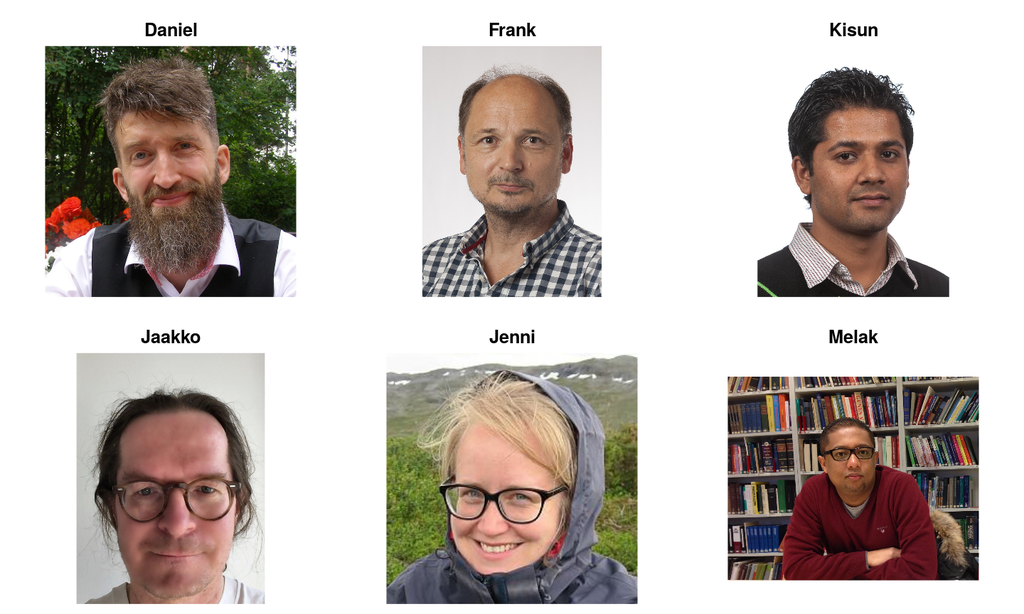

## Bioinformatics Network at Luke

Bioinformatics Network at Luke

Current state of the Bioinformatics Network at Luke:

- We started to connect people working in Bioinformatics
- Teaching has begun:
  - Introduction to Metagenomics
  - Introduction to Snakemake
  - Introduction to RNA-Seq
- Establishing analysis pipelines
- Improvement of visibility of the group
- Network-Meeting scheduled for autumn

## Joining the network

Joining the network

- If you are working in bioinformatics, please feel free to contact me to join the network
- If you need bioinformatics support, please contact persons directly. If they are overworked, they will redirect you to others
- Don’t be shy, ask! Contact various networks before you spend time and efforts to save time and efforts!
- If there is demand for education, please feel free to reach out as well
- Join our (rather silent) Teams channel ( code: r4pjdgk )

## Overview of our work

## The field of Bioinformatics

Location of Bioinformatics

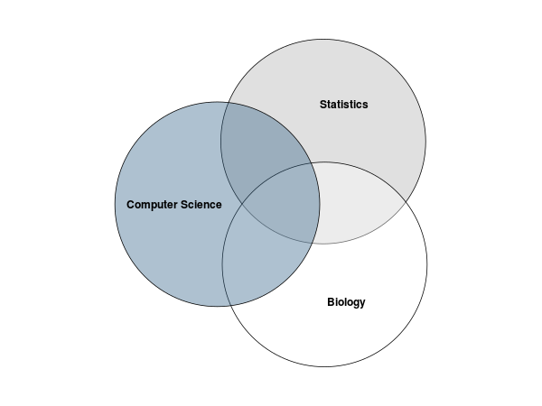

## Metagenomics

Metagenomics

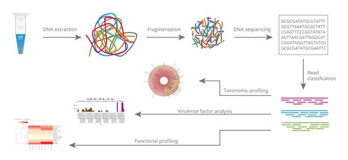

## Transcriptomics (DE, ncRNA, eQTL)

Transcriptomics

[figure not shown]

## Variant calling (SNP, GWAS, QTL)

Variant calling

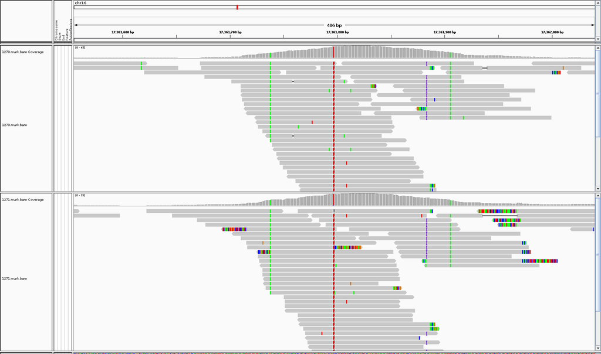

## Genome assembly and annotation

Novel genome assembly and annotation

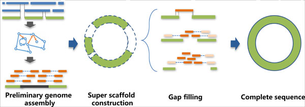

## eDNA - environmental DNA

Environmental DNA

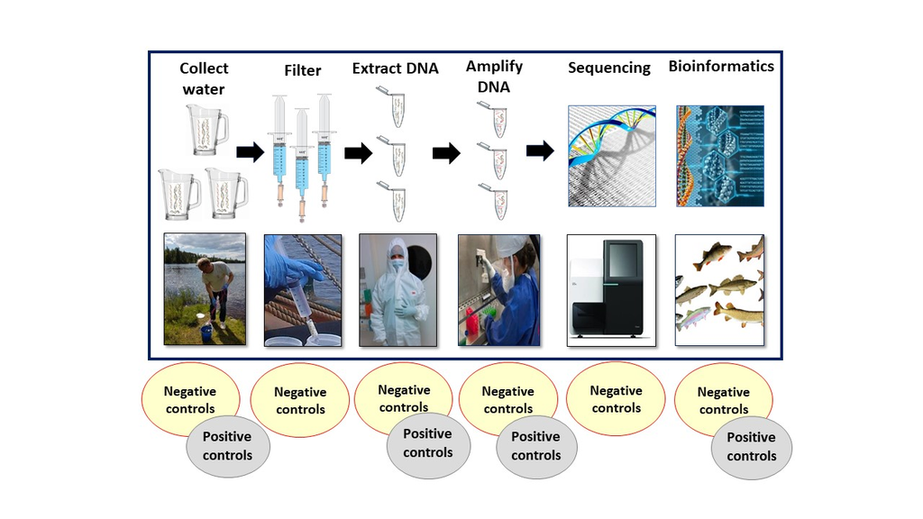

## Other areas

- Development of tailored statistical methods
- Genotyping-by-Sequencing (GBS)
- Programming (R, Python, …)
- Under development: CRISPR/Cas9 data analysis
- …

## Thank you!

Please reach out if you feel you would need support or would like to join the network!